# RateMyProfessors

# Indroduction

Most current college students are aware of RateMyProfessors.com, the go-to review site for higher ed. Student of their own volition may review both professors and colleges to help future students make decisions. As with any review site, reviews range from scathing to celebratory, but how accurate are they?

As a small introduction to the idea, I took review and teacher data from RateMyProfessors for the entirety of Brigham Young University - Idaho (my alma mater). What follows are the graphical and statistical insights I found most fascinating from this data set.

#### Show Data

To collect the data, I found an api on github for web scraping RateMyProfessor, then modified the Python code to fix it and hit it with a hammer until I got what I wanted. It took considerable time because this was my first experience web scraping with Python.

Unfortunately, I forgot to tie the professor name to each review, but the second table shows overall rating and other data collected about professors (in case a professor is interested in looking up what data is collected on them).

```r
datatable(ratings %>% head(500))
```

|  | attendance | clarityColor | easyColor | helpColor | helpCount | id | notHelpCount | onlineClass | quality | rClarity | rClass | rComments | rDate | rEasy | rEasyString | rErrorMsg | rHelpful | rInterest | rOverall | rOverallString | rStatus | rTextBookUse | rTimestamp | rWouldTakeAgain | sId | takenForCredit | teacher | teacherGrade | teacherRatingTags | … |
| --- | --- | --- | --- | --- | --- | --- | --- | --- | --- | --- | --- | --- | --- | --- | --- | --- | --- | --- | --- | --- | --- | --- | --- | --- | --- | --- | --- | --- | --- | --- |
| 1 | Mandatory | good | average | good | 1 | 29705550 | 0 |  | good | 4 | FDSCI101 | She is very sweet and caring, her clicker quizzes sometimes aren't related to the tests... but has very good notes and truly cares about her students, I would DEFIANTLY take her again! | 03/27/2018 | 2 | 2 |  | 4 | N/A | 4 | 4 | 1 | No | 1522182170000 | Yes | 1754 | Yes |  | A- | [] | … |
| 2 | N/A | good | average | good | 0 | 29691494 | 1 |  | awesome | 5 | FDSCI101 | Sister Huggins is a great teacher! I would leave class thinking about the things we learned and share them with others. She is very thorough and the assignments are very simple and prepare you for cla… | 03/24/2018 | 2 | 2 |  | 5 | N/A | 5 | 5 | 1 | No | 1521909010000 | Yes | 1754 | Yes |  | A | ['Clear grading criteria', 'Amazing lectures '] | … |
| 3 | N/A | good | average | good | 0 | 29217196 | 0 |  | awesome | 5 | FDSCI201 | She is an Awesome teacher, loved her class. I normally hate science, but this class was super fun. I felt like I learned a lot in her class. She is funny. The assignments don't take to long, and are p… | 12/15/2017 | 3 | 3 |  | 5 | N/A | 5 | 5 | 1 | Yes | 1513335920000 | Yes | 1754 | Yes |  |  | ['Gives good feedback', 'Caring'] | … |
| 4 | Mandatory | poor | average | poor | 1 | 28545247 | 0 |  | awful | 1 | FDSCI101 | She is a wonderful woman, but honestly wasn't that great of a teacher. I felt the notes we wrote during class were never used on tests, so I felt there was no point to even take notes. All of her ques… | 07/20/2017 | 3 | 3 |  | 1 | N/A | 1 | 1 | 1 | No | 1500555207000 | No | 1754 | Yes |  |  | ['Get ready to read', 'Lots of homework'] | … |
| 5 | Mandatory | good | good | good | 0 | 28475116 | 0 |  | good | 4 | FDSCI101 | She was super caring about our grades and is willing to work with you if you need help. | 06/21/2017 | 4 | 4 |  | 4 | N/A | 4 | 4 | 1 | Yes | 1498080844000 | Yes | 1754 | Yes |  |  | ['EXTRA CREDIT', 'Accessible outside class', 'Caring'] | … |
| 6 | Mandatory | average | good | average | 1 | 28460672 | 0 |  | poor | 2 | FDSCI101 | I haven't loved science classes in the past so I wasn't expecting to love this class either. She gives too much busy work, a short assignment before and after each class to prove you went to class, lo… | 06/16/2017 | 5 | 5 |  | 2 | N/A | 2 | 2 | 1 | No | 1497633392000 | No | 1754 | Yes |  |  | ['Lots of homework', 'Tough grader'] | … |
| 7 | Mandatory | good | average | good | 0 | 28452903 | 0 |  | awesome | 5 | FDSCI101 | Sister Hurst's passion for science is evident and rubs off on you making class enjoyable. People say the material is boring because its about "rocks" and space and what not but if you open your mind y… | 06/14/2017 | 3 | 3 |  | 5 | N/A | 5 | 5 | 1 | No | 1497447410000 | Yes | 1754 | Yes |  | INC | ['Lots of homework', 'Caring', 'Hilarious'] | … |
| 8 | Mandatory | average | good | average | 1 | 27308323 | 0 |  | poor | 2 | FDSCI101 | Sister Hurst is a wonderful woman. She is very passionate about what she teaches, and you can tell she really enjoys it. There is a ton of homework that can be a little overwhelming at times, and with… | 12/02/2016 | 4 | 4 |  | 2 | N/A | 2 | 2 | 1 | No | 1480637710000 | No | 1754 | Yes |  | A+ | ['Lecture heavy', 'Group projects', 'Lots of homework'] | … |
| 9 | Mandatory | average | good | average | 1 | 27275237 | 0 |  | poor | 2 | FDSCI101 | Sister Hurst assigns a vast amount of homework. There is an essay, and a quiz, due weekly, all outside class. But, don't expect to hear much of anything from her on any of the assigned reading and hom… | 11/29/2016 | 4 | 4 |  | 2 | N/A | 2 | 2 | 1 | No | 1480433140000 | No | 1754 | Yes |  |  | ['Lots of homework', 'So many papers', 'Get ready to read'] | … |
| 10 | Not Mandatory | good | average | good | 1 | 27142075 | 0 |  | good | 4 | FDSCI201 | I really enjoyed this class and felt like I learned lots of new information. She is very enthusiastic about the sciences. Do your homework and reading and you will get an A! | 11/07/2016 | 2 | 2 |  | 4 | N/A | 4 | 4 | 1 | No | 1478524353000 | Yes | 1754 | Yes |  | A | ['Group projects', 'Clear grading criteria', 'Accessible outside class'] | … |

[output cut: 490 more lines]

```r
datatable(prof %>% head(500))
```

|  | tDept | tSid | institution_name | tFname | tMiddlename | tLname | tid | tNumRatings | rating_class | contentType | categoryType | overall_rating |
| --- | --- | --- | --- | --- | --- | --- | --- | --- | --- | --- | --- | --- |
| 1 | Physics | 1754 | Brigham Young University - Idaho | Collins |  | Alan | 3021921 | 0 | zero | TEACHER | PROFESSOR | N/A |
| 2 | Interior Design | 1754 | Brigham Young University - Idaho | Toni |  | Elorrieta | 2986890 | 0 | zero | TEACHER | PROFESSOR | N/A |
| 3 | General Studies | 1754 | Brigham Young University - Idaho | Coreen |  | (Hurst) Huggins | 2021911 | 26 | average | TEACHER | PROFESSOR | 3.0 |
| 4 | Religion | 1754 | Brigham Young University - Idaho | David |  | Aaron | 2711322 | 0 | zero | TEACHER | PROFESSOR | N/A |
| 5 | Geology | 1754 | Brigham Young University - Idaho | Jason |  | Aase | 809410 | 30 | good | TEACHER | PROFESSOR | 4.4 |
| 6 | Online Learning | 1754 | Brigham Young University - Idaho | Dawn |  | Abbott | 2472024 | 18 | good | TEACHER | PROFESSOR | 4.3 |
| 7 | Art | 1754 | Brigham Young University - Idaho | Joshua |  | Abegglen | 1421923 | 17 | good | TEACHER | PROFESSOR | 4.7 |
| 8 | Sociology | 1754 | Brigham Young University - Idaho | Michael |  | Abel | 922527 | 90 | good | TEACHER | PROFESSOR | 3.6 |
| 9 | English | 1754 | Brigham Young University - Idaho | Courtney |  | Abenroth | 1868481 | 9 | good | TEACHER | PROFESSOR | 4.7 |
| 10 | Military Science | 1754 | Brigham Young University - Idaho | Tiffany |  | Abriam | 2242218 | 1 | good | TEACHER | PROFESSOR | 5.0 |

[output cut: 490 more lines]

### Student Grade Distribution

The data available from RateMyProfessor contains 76,958 student reviews. The largest grouping of people do not list a grade in their review, but there is a disproportionately high number of A’s for those who do, and higher grades are more common that lower ones in the reviews given.

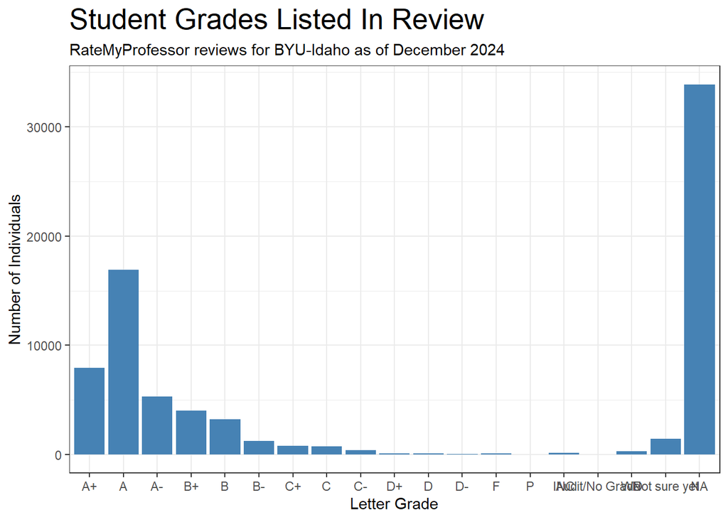

```r
ggplot(ratings, aes(teacherGrade)) +
  geom_bar(fill = "steelblue") +
  theme_bw() +
  labs(
    title = "Student Grades Listed In Review",
    subtitle = "RateMyProfessor reviews for BYU-Idaho as of December 2024",
    x = "Letter Grade",
    y = "Number of Individuals"
  ) +
  theme(
    plot.title = element_text(size = 20)
  )
```

```r
table(ratings$teacherGrade) %>% pander()
```

Table continues below

| A+ | A | A- | B+ | B | B- | C+ | C | C- | D+ | D | D- |
| --- | --- | --- | --- | --- | --- | --- | --- | --- | --- | --- | --- |
| 7949 | 16926 | 5334 | 4013 | 3240 | 1273 | 801 | 742 | 408 | 134 | 114 | 64 |

| F | P | INC | Audit/No Grade | WD | Not sure yet |
| --- | --- | --- | --- | --- | --- |
| 128 | 9 | 172 | 26 | 293 | 1454 |

### Students’ Perspectives are Tied to Grades

#### Average

The graph below shows grade received compared to teacher rating given. Individual reviews are grouped by the grade the reviewer received, then the rating is averaged for each group. This graph contains data across all BYUI student reviews on RateMyProfessor that reported their grade received. There is an incredible, visibly strong linear relationship.

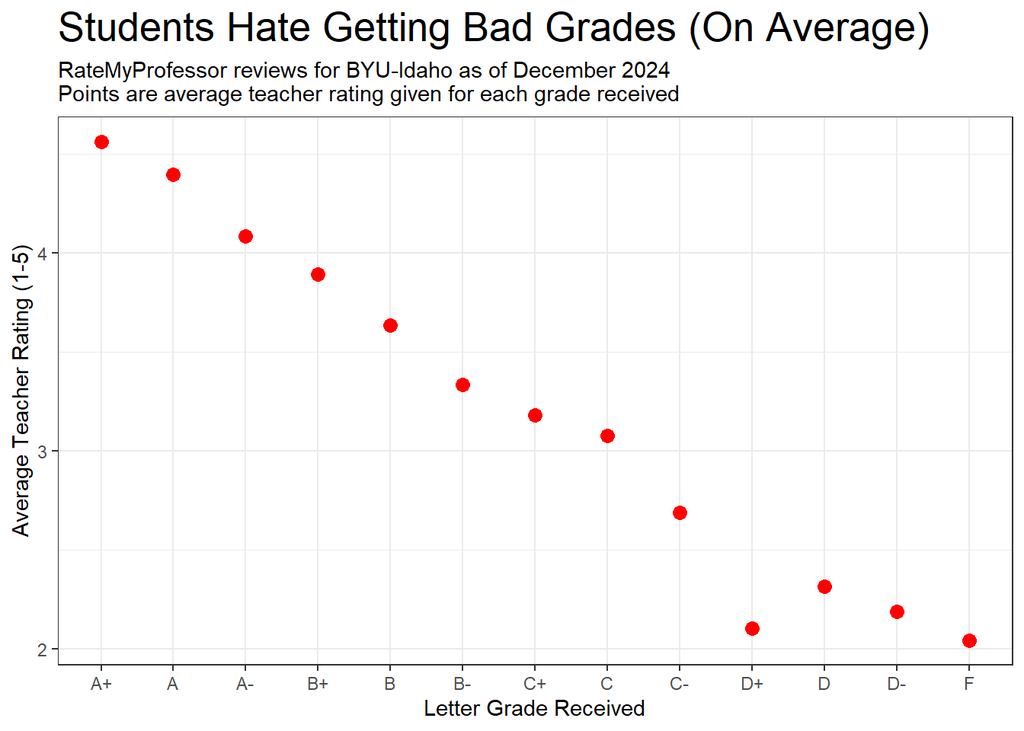

```r
ratings %>%
  group_by(teacherGrade) %>%
  summarize(
    ave_rating = mean(rOverall)
  ) %>%
  ungroup() %>%
  filter(teacherGrade %in% letter_grades) %>%
  ggplot(aes(teacherGrade, ave_rating)) +
  geom_point(color = "red", size = 3) +
  theme_bw() +
  labs(
    title = "Students Hate Getting Bad Grades (On Average)",
    subtitle = "RateMyProfessor reviews for BYU-Idaho as of December 2024\nPoints are average teacher rating given for each grade received",
    x = "Letter Grade Received",
    y = "Average Teacher Rating (1-5)"
  ) +
  theme(
    plot.title = element_text(size = 20)
  )
```

Interesting to note is the exception to the linear relationship in the D+ rating. This could be because the students failed and are angry that their teacher didn’t bump up their grade slightly so they wouldn’t have to retake the class.

#### Normalized Density

While the averaged graph is clearest to notice this trend, I find it important to get as close to individual level data as much as reasonable and not rely solely on high level summaries. This 2d density plot shows how many reviews were given with each category combination, normalized by grade category size. We can visibly see that there is a lot of variation in grades received and ratings given, but there is still a visible downward trend.

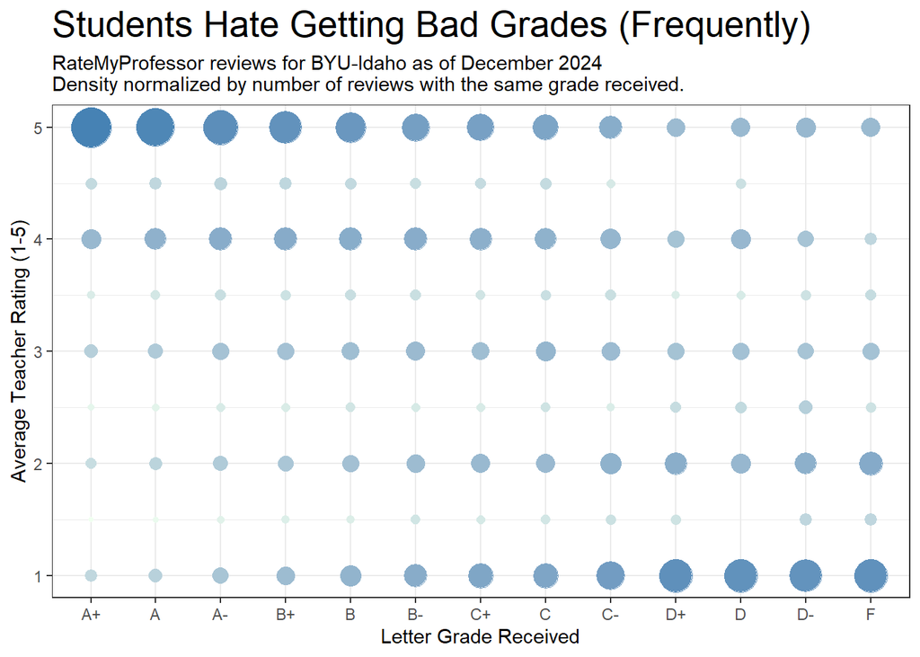

```r
just_grade_rating <- ratings %>%
  select(teacherGrade, rOverall) %>%
  filter(teacherGrade %in% letter_grades) %>%
  group_by(teacherGrade, rOverall) %>%
  summarize(frequency = n())

grade_count <- ratings %>%
  group_by(teacherGrade) %>%
  summarize(grade_count = n())

# glimpse(grade_count)
# glimpse(just_grade_rating)

just_grade_rating <- just_grade_rating %>% left_join(grade_count) %>%
  mutate(
    normalized_frequency = frequency / grade_count
  )

ggplot(just_grade_rating, aes(teacherGrade, rOverall, size = normalized_frequency, color = sqrt(sqrt((normalized_frequency))))) +
  geom_point() +
  scale_size(range = c(1, 10)) +
  scale_color_gradient(low = "#F0FFF0", high = "steelblue") +
  theme_bw() +
  labs(
    title = "Students Hate Getting Bad Grades (Frequently)",
    subtitle = "RateMyProfessor reviews for BYU-Idaho as of December 2024\nDensity normalized by number of reviews with the same grade received.",
    x = "Letter Grade Received",
    y = "Average Teacher Rating (1-5)"
  ) +
  theme(
    legend.position = "none",
    plot.title = element_text(size = 20)
  )
```

To explain more about what this chart is, the upper left point is the number of people that received and A+ and gave the teacher a rating of 5. Then, because we saw that there are a disproportionate number of A+ reviews compared to D reviews, each point is normalized by number of reviews in its grade group. The point with a rating of 5 in the A+ group would be divided by number of people that received an A+. Without normalizing, the chart is a better depiction of number of people that received each grade.

### Conclusions

Notably, this demonstration is only correlational, but still useful as a point of interest and investigation. It could be interpreted in several ways:

- Our perspectives are influenced by the system we are in, particularly the grading system in a schooling setting. Giving good grades could potentially impact learning ability (or simply how well they like their teacher).
- People who like their teachers work harder in their class.
- People are highly influenced by their emotions and are self-centric.
- Teachers who grade mercifully are simply more likable people.
- There is something about the type of measure being used that influences the way the students report. In other words, a general score from 1 to 5 that is simply a “rating”. There is nothing specific to what they are rating. That ambiguity might tie the unspecific rating they receive (grade) to the unspecific rating they give.

This analysis doesn’t establish causality. There is simply a very interesting correlation. I would suppose the RateMyProfessor rating is not a measure of how good the teacher is, how friendly they are, or how highly esteemed they are. It seems to be all of those things, or a separate measure in and of itself.